# generalized_similarity

This notebook will take in a list of questions and calculate sentence similarity scores between each of them using the BERT model. We will begin by importing the dataset itself below. Credit for the "how-to" and code below goes to this [fantastic article](https://towardsdatascience.com/bert-for-measuring-text-similarity-eec91c6bf9e1). The main instruction is that the column with the text must be called 'text' for this script to work.

```python
# Constants
dataset = 'curated_philosophical_questions'
model_name = 'multi-qa-mpnet-base-dot-v1' #'dmis-lab/biobert-base-cased-v1.2' #'multi-qa-mpnet-base-dot-v1' # all-mpnet-base-v2
cutoff = 0.4 # Note that cutoffs differ depending on the model used. 0.5 for all-mpnet-base-v2
```

```python
import pandas as pd
dat = pd.read_csv('../data/processed/' + dataset + '.csv')
dat
```

|  | Person | Source | Link | text |
| --- | --- | --- | --- | --- |
| 0 | C.B. Daniels | Conversation Starters World | https://conversationstartersworld.com/philosophical-questions/ | What harsh truths do you prefer to ignore? |
| 1 | C.B. Daniels | Conversation Starters World | https://conversationstartersworld.com/philosophical-questions/ | Is free will real or just an illusion? |
| 2 | C.B. Daniels | Conversation Starters World | https://conversationstartersworld.com/philosophical-questions/ | Is there a meaning to life? If so, what is it? |
| 3 | C.B. Daniels | Conversation Starters World | https://conversationstartersworld.com/philosophical-questions/ | Where is the line between art and not art? |
| 4 | C.B. Daniels | Conversation Starters World | https://conversationstartersworld.com/philosophical-questions/ | What should be the goal of humanity? |
| ... | ... | ... | ... | ... |
| 197 | C.B. Daniels | Conversation Starters World | https://conversationstartersworld.com/philosophical-questions/ | Should full access to the internet be a fundamental human right? |
| 198 | C.B. Daniels | Conversation Starters World | https://conversationstartersworld.com/philosophical-questions/ | Has the invention of the atomic bomb made the world a more peaceful place? |
| 199 | C.B. Daniels | Conversation Starters World | https://conversationstartersworld.com/philosophical-questions/ | Do you think the singularity will occur? If so, what time frame do you think it will happen in? |
| 200 | C.B. Daniels | Conversation Starters World | https://conversationstartersworld.com/philosophical-questions/ | If we could control emotions through technology, should we? |
| 201 | C.B. Daniels | Conversation Starters World | https://conversationstartersworld.com/philosophical-questions/ | Is there a limit to what humans can create through technology and science? |

202 rows × 4 columns

```python
from sentence_transformers import SentenceTransformer

sentences = dat["text"].tolist()
model = SentenceTransformer(model_name)

sentence_embeddings = model.encode(sentences)
sentence_embeddings.shape
```

[output not shown]

```
(202, 768)
```

```python
from sklearn.metrics.pairwise import cosine_similarity
import numpy as np

cos_sim = cosine_similarity(
    [sentence_embeddings[20]],
    sentence_embeddings
).tolist()

df = pd.DataFrame({'text': sentences,
            'similarity': cos_sim[0]})

# Arrange by similarity
pd.set_option('display.max_colwidth', None)
display(df.sort_values(by = 'similarity', ascending = False))
```

|  | text | similarity |
| --- | --- | --- |
| 20 | What do you think would be humanity’s reaction to the discovery of extraterrestrial life? | 1.000000 |
| 108 | If humanity was put on trial by an advanced race of aliens, how would you defend humanity and argue for its continued existence? | 0.651333 |
| 82 | Would it be more frightening to discover that humans are the most advanced species in the universe or that we are far from being the most advanced species in the universe? | 0.607382 |
| 191 | What scientific breakthrough would have the biggest effect on humanity? | 0.562743 |
| 124 | If it was discovered that most animals were conscious of their existence and eventual death, what would be the ramifications of that discovery? | 0.558233 |
| ... | ... | ... |
| 95 | Why do we resist doing things that we know are good for our well-being while craving things that are detrimental to our well-being? | 0.207444 |
| 91 | Is it possible that someone’s genes might affect their political leanings? If no, why not? If so, what would be the ramifications? | 0.197444 |
| 24 | Does hardship make a person stronger? If so, under what conditions and at what point is it too much hardship? If not, what makes a person stronger? | 0.159018 |
| 121 | Can morality ever be objective or is it always subjective? If it can be objective, in what instances? If it’s always subjective, how do we decide whose concept of morality is correct? | 0.148967 |
| 90 | Is the concept of “you” continuous or does past “you” continually fade into present and future “you”? In other words, what part of “you” sticks around over time considering that the atoms that make up… | 0.120915 |

202 rows × 2 columns

We were going to run a UMAP on the vector space to get some intuition around what it looks like, but because UMAP has issues with python 3.9 at the moment, we're going to jump right to making a cosine similarity matrix that we will then turn into a graph.

```python
import sklearn

dist = sklearn.metrics.pairwise.cosine_distances(sentence_embeddings)
dist

# nn = sklearn.neighbors.kneighbors_graph(sentence_embeddings, n_neighbors = 1)
# nn
```

```
array([[0.        , 0.68917525, 0.67561233, ..., 0.7377938 , 0.64611244,
        0.7612562 ],
       [0.68917525, 0.        , 0.5191412 , ..., 0.6417422 , 0.5366794 ,
        0.55929875],
       [0.67561233, 0.5191412 , 0.        , ..., 0.7190081 , 0.6869738 ,
        0.58177465],
       ...,
       [0.7377938 , 0.6417422 , 0.7190081 , ..., 0.        , 0.7546375 ,
        0.5302633 ],
       [0.64611244, 0.5366794 , 0.6869738 , ..., 0.7546375 , 0.        ,
        0.5702214 ],
       [0.7612562 , 0.55929875, 0.58177465, ..., 0.5302633 , 0.5702214 ,
        0.        ]], dtype=float32)
```

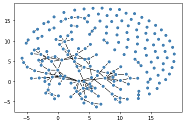

```python
import igraph as ig
import matplotlib.pyplot as plt

dist = np.where(dist == 0, 1, dist) # For the boolean below. Can't figure out compound boolean.

g = ig.Graph.Adjacency(dist < cutoff) # Need to convert to boolean
g = g.as_undirected()

if dat.shape[0] < 1000:
    fig, ax = plt.subplots()
    ig.plot(g, target=ax)
```

```python
deg = g.degree()
btw = g.betweenness()
dat['degree'] = g.degree()
dat['betweenness'] = g.betweenness()
display(dat.sort_values(by='degree', ascending=False))
display(dat.sort_values(by='betweenness', ascending=False))
```

|  | Person | Source | Link | text | degree | betweenness |
| --- | --- | --- | --- | --- | --- | --- |
| 43 | C.B. Daniels | Conversation Starters World | https://conversationstartersworld.com/philosophical-questions/ | What is the most important goal every person should have? | 10 | 3211.773810 |
| 56 | C.B. Daniels | Conversation Starters World | https://conversationstartersworld.com/philosophical-questions/ | What would you genetically change about humans to make them a better species? | 9 | 1044.125000 |
| 168 | C.B. Daniels | Conversation Starters World | https://conversationstartersworld.com/philosophical-questions/ | What is the most important right our government allows for? | 9 | 1584.690476 |
| 189 | C.B. Daniels | Conversation Starters World | https://conversationstartersworld.com/philosophical-questions/ | Is technological progress inevitable as long as humans exist or can it be stopped? | 7 | 238.833333 |
| 6 | C.B. Daniels | Conversation Starters World | https://conversationstartersworld.com/philosophical-questions/ | What does it mean to live a good life? | 7 | 886.761905 |
| ... | ... | ... | ... | ... | ... | ... |
| 141 | C.B. Daniels | Conversation Starters World | https://conversationstartersworld.com/philosophical-questions/ | If I steal a loaf of bread from you and eat it, when does the bread itself cease to be yours and becomes mine? | 0 | 0.000000 |
| 140 | C.B. Daniels | Conversation Starters World | https://conversationstartersworld.com/philosophical-questions/ | How does this human trait of morality dependent on distance shape our world? | 0 | 0.000000 |
| 139 | C.B. Daniels | Conversation Starters World | https://conversationstartersworld.com/philosophical-questions/ | Why are humans so fascinated by mass murderers if their actions are universally considered evil and vile? | 0 | 0.000000 |
| 137 | C.B. Daniels | Conversation Starters World | https://conversationstartersworld.com/philosophical-questions/ | What is your definition of evil? | 0 | 0.000000 |
| 0 | C.B. Daniels | Conversation Starters World | https://conversationstartersworld.com/philosophical-questions/ | What harsh truths do you prefer to ignore? | 0 | 0.000000 |

202 rows × 6 columns

|  | Person | Source | Link | text | degree | betweenness |
| --- | --- | --- | --- | --- | --- | --- |
| 43 | C.B. Daniels | Conversation Starters World | https://conversationstartersworld.com/philosophical-questions/ | What is the most important goal every person should have? | 10 | 3211.773810 |
| 168 | C.B. Daniels | Conversation Starters World | https://conversationstartersworld.com/philosophical-questions/ | What is the most important right our government allows for? | 9 | 1584.690476 |
| 191 | C.B. Daniels | Conversation Starters World | https://conversationstartersworld.com/philosophical-questions/ | What scientific breakthrough would have the biggest effect on humanity? | 7 | 1235.275000 |
| 56 | C.B. Daniels | Conversation Starters World | https://conversationstartersworld.com/philosophical-questions/ | What would you genetically change about humans to make them a better species? | 9 | 1044.125000 |
| 42 | C.B. Daniels | Conversation Starters World | https://conversationstartersworld.com/philosophical-questions/ | What life-altering things should every human ideally get to experience at least once in their lives? | 5 | 1037.250000 |
| ... | ... | ... | ... | ... | ... | ... |
| 93 | C.B. Daniels | Conversation Starters World | https://conversationstartersworld.com/philosophical-questions/ | Would selectively breeding an animal such as a dog based on intelligence, increase its intelligence over time? If so, how intelligent could dogs become? If not, how does intelligence emerge in a speci… | 0 | 0.000000 |
| 94 | C.B. Daniels | Conversation Starters World | https://conversationstartersworld.com/philosophical-questions/ | Are there limits to human creativity? | 2 | 0.000000 |
| 95 | C.B. Daniels | Conversation Starters World | https://conversationstartersworld.com/philosophical-questions/ | Why do we resist doing things that we know are good for our well-being while craving things that are detrimental to our well-being? | 0 | 0.000000 |
| 96 | C.B. Daniels | Conversation Starters World | https://conversationstartersworld.com/philosophical-questions/ | Is it be possible for humans to create something completely novel and new that is based on nothing that previously existed? Or is human creativity just rearranging and building on previous ideas? | 2 | 0.000000 |
| 101 | C.B. Daniels | Conversation Starters World | https://conversationstartersworld.com/philosophical-questions/ | Is a sense of humor a byproduct of consciousness or something else entirely? | 1 | 0.000000 |

202 rows × 6 columns

From here, we run clustering to see if the the quesitons group into particular themes. We will use Louvain clustering, as it is often used in graph-based analysis.

```python
clust = ig.Graph.community_multilevel(g)
#df = pd.DataFrame({'name': dat['Question'], 'cluster': clust.membership})
dat['cluster'] = clust.membership

# Get cluster ID, mine the per-cluster topics
for i in pd.unique(dat['cluster']):
    curr = dat[dat['cluster'] == i]
    if curr.shape[0] > 5:
        display(curr.sort_values(by='degree', ascending=False))
```

|  | Person | Source | Link | text | degree | betweenness | cluster |
| --- | --- | --- | --- | --- | --- | --- | --- |
| 6 | C.B. Daniels | Conversation Starters World | https://conversationstartersworld.com/philosophical-questions/ | What does it mean to live a good life? | 7 | 886.761905 | 2 |
| 19 | C.B. Daniels | Conversation Starters World | https://conversationstartersworld.com/philosophical-questions/ | Where do you find meaning in your life? | 7 | 154.452381 | 2 |
| 33 | C.B. Daniels | Conversation Starters World | https://conversationstartersworld.com/philosophical-questions/ | What is the best way for a person to attain happiness? | 6 | 498.928571 | 2 |
| 54 | C.B. Daniels | Conversation Starters World | https://conversationstartersworld.com/philosophical-questions/ | What activities cause you to feel like you are living life to the fullest? | 5 | 124.952381 | 2 |
| 2 | C.B. Daniels | Conversation Starters World | https://conversationstartersworld.com/philosophical-questions/ | Is there a meaning to life? If so, what is it? | 4 | 649.452381 | 2 |
| 58 | C.B. Daniels | Conversation Starters World | https://conversationstartersworld.com/philosophical-questions/ | Where do you think is the most worthwhile place to find meaning in life? Work, family, hobby, religion, philosophy, helping others, all the small miracles, or something else entirely? | 4 | 18.166667 | 2 |
| 69 | C.B. Daniels | Conversation Starters World | https://conversationstartersworld.com/philosophical-questions/ | What is the best path to find truth; science, math, art, philosophy, or something else? | 3 | 12.309524 | 2 |
| 60 | C.B. Daniels | Conversation Starters World | https://conversationstartersworld.com/philosophical-questions/ | Is a life that focuses on avoiding pain and seeking out pleasure a good and worthwhile life? Why or why not? | 2 | 100.000000 | 2 |
| 74 | C.B. Daniels | Conversation Starters World | https://conversationstartersworld.com/philosophical-questions/ | Is happiness just chemicals flowing through your brain or something more? | 2 | 198.000000 | 2 |
| 102 | C.B. Daniels | Conversation Starters World | https://conversationstartersworld.com/philosophical-questions/ | Are intelligence and happiness tied together in any way? If you are highly intelligent, is it more likely that you’ll be more, or less happy? | 2 | 100.000000 | 2 |
| 23 | C.B. Daniels | Conversation Starters World | https://conversationstartersworld.com/philosophical-questions/ | Is suffering a necessary part of the human condition? What would people who never suffered be like? | 1 | 0.000000 | 2 |
| 37 | C.B. Daniels | Conversation Starters World | https://conversationstartersworld.com/philosophical-questions/ | Is intelligence or wisdom more useful? | 1 | 0.000000 | 2 |
| 62 | C.B. Daniels | Conversation Starters World | https://conversationstartersworld.com/philosophical-questions/ | What percentage of your life do you feel truly alive? When do you feel that way? How can you feel that way more often? | 1 | 0.000000 | 2 |

|  | Person | Source | Link | text | degree | betweenness | cluster |
| --- | --- | --- | --- | --- | --- | --- | --- |
| 163 | C.B. Daniels | Conversation Starters World | https://conversationstartersworld.com/philosophical-questions/ | Is the cultural trend of individualism and the rejection of collectivism a beneficial or detrimental trend? | 5 | 337.625 | 3 |
| 26 | C.B. Daniels | Conversation Starters World | https://conversationstartersworld.com/philosophical-questions/ | What benefits does art provide society? Does art hurt society in any way? | 4 | 133.125 | 3 |
| 39 | C.B. Daniels | Conversation Starters World | https://conversationstartersworld.com/philosophical-questions/ | What do you contribute back to society? | 3 | 301.600 | 3 |
| 166 | C.B. Daniels | Conversation Starters World | https://conversationstartersworld.com/philosophical-questions/ | What are the benefits and drawbacks of diversity in society? | 3 | 99.625 | 3 |
| 169 | C.B. Daniels | Conversation Starters World | https://conversationstartersworld.com/philosophical-questions/ | Has social media been a net positive or a net negative for our society? Why? | 3 | 74.625 | 3 |
| 161 | C.B. Daniels | Conversation Starters World | https://conversationstartersworld.com/philosophical-questions/ | Is the human tendency to create groups an overall positive or a negative trait in terms of general human flourishing? | 2 | 100.000 | 3 |
| 3 | C.B. Daniels | Conversation Starters World | https://conversationstartersworld.com/philosophical-questions/ | Where is the line between art and not art? | 1 | 0.000 | 3 |
| 176 | C.B. Daniels | Conversation Starters World | https://conversationstartersworld.com/philosophical-questions/ | Will humanity ever be able to escape tribalism and the creation of in and out groups? Should it? | 1 | 0.000 | 3 |
| 182 | C.B. Daniels | Conversation Starters World | https://conversationstartersworld.com/philosophical-questions/ | Was the agricultural revolution and the explosion of civilizations that came from it an overall good thing for humans or a negative? In other words, would it have been better or worse for people to st… | 1 | 0.000 | 3 |

|  | Person | Source | Link | text | degree | betweenness | cluster |
| --- | --- | --- | --- | --- | --- | --- | --- |
| 43 | C.B. Daniels | Conversation Starters World | https://conversationstartersworld.com/philosophical-questions/ | What is the most important goal every person should have? | 10 | 3211.773810 | 4 |
| 56 | C.B. Daniels | Conversation Starters World | https://conversationstartersworld.com/philosophical-questions/ | What would you genetically change about humans to make them a better species? | 9 | 1044.125000 | 4 |
| 191 | C.B. Daniels | Conversation Starters World | https://conversationstartersworld.com/philosophical-questions/ | What scientific breakthrough would have the biggest effect on humanity? | 7 | 1235.275000 | 4 |
| 4 | C.B. Daniels | Conversation Starters World | https://conversationstartersworld.com/philosophical-questions/ | What should be the goal of humanity? | 5 | 657.250000 | 4 |
| 22 | C.B. Daniels | Conversation Starters World | https://conversationstartersworld.com/philosophical-questions/ | If you could teach everyone in the world one concept, what concept would have the biggest positive impact on humanity? | 5 | 560.250000 | 4 |
| 42 | C.B. Daniels | Conversation Starters World | https://conversationstartersworld.com/philosophical-questions/ | What life-altering things should every human ideally get to experience at least once in their lives? | 5 | 1037.250000 | 4 |
| 18 | C.B. Daniels | Conversation Starters World | https://conversationstartersworld.com/philosophical-questions/ | How would humanity change if all humans’ life expectancy was significantly increased (let’s say to around 500 years)? | 3 | 173.666667 | 4 |
| 47 | C.B. Daniels | Conversation Starters World | https://conversationstartersworld.com/philosophical-questions/ | Can human nature be changed? Should it be changed? | 2 | 100.000000 | 4 |
| 31 | C.B. Daniels | Conversation Starters World | https://conversationstartersworld.com/philosophical-questions/ | Is humanity headed in the right or wrong direction? | 1 | 0.000000 | 4 |
| 45 | C.B. Daniels | Conversation Starters World | https://conversationstartersworld.com/philosophical-questions/ | What are you capable of achieving? | 1 | 0.000000 | 4 |
| 118 | C.B. Daniels | Conversation Starters World | https://conversationstartersworld.com/philosophical-questions/ | Are people ethically obligated to improve themselves? | 1 | 0.000000 | 4 |
| 145 | C.B. Daniels | Conversation Starters World | https://conversationstartersworld.com/philosophical-questions/ | Would the world be a better or worse place if everyone looked the same? | 1 | 0.000000 | 4 |
| 194 | C.B. Daniels | Conversation Starters World | https://conversationstartersworld.com/philosophical-questions/ | If a robust and cheap genetic engineering industry existed, would you have your genes edited? If so, what genetic changes would you choose to make? If not, why not? | 1 | 0.000000 | 4 |

|  | Person | Source | Link | text | degree | betweenness | cluster |
| --- | --- | --- | --- | --- | --- | --- | --- |
| 75 | C.B. Daniels | Conversation Starters World | https://conversationstartersworld.com/philosophical-questions/ | Why are humans so susceptible to magical thinking? | 3 | 9.0 | 5 |
| 38 | C.B. Daniels | Conversation Starters World | https://conversationstartersworld.com/philosophical-questions/ | Which of your beliefs are justified and which ones aren’t? | 2 | 5.0 | 5 |
| 84 | C.B. Daniels | Conversation Starters World | https://conversationstartersworld.com/philosophical-questions/ | So, which of your beliefs are most likely to be wrong and which are most liable to be true? | 2 | 8.0 | 5 |
| 86 | C.B. Daniels | Conversation Starters World | https://conversationstartersworld.com/philosophical-questions/ | Why are humans so confident in beliefs that can’t be proven? | 2 | 9.0 | 5 |
| 7 | C.B. Daniels | Conversation Starters World | https://conversationstartersworld.com/philosophical-questions/ | Why do we dream? | 1 | 0.0 | 5 |
| 51 | C.B. Daniels | Conversation Starters World | https://conversationstartersworld.com/philosophical-questions/ | Which is a more valid point of view or are they both equally valid? | 1 | 0.0 | 5 |
| 88 | C.B. Daniels | Conversation Starters World | https://conversationstartersworld.com/philosophical-questions/ | Why do humans have such a strong urge to distract ourselves from the real world? | 1 | 0.0 | 5 |

|  | Person | Source | Link | text | degree | betweenness | cluster |
| --- | --- | --- | --- | --- | --- | --- | --- |
| 72 | C.B. Daniels | Conversation Starters World | https://conversationstartersworld.com/philosophical-questions/ | What in life is truly objective and not subjective? | 4 | 425.333333 | 6 |
| 8 | C.B. Daniels | Conversation Starters World | https://conversationstartersworld.com/philosophical-questions/ | Where does your self-worth come from? | 3 | 62.833333 | 6 |
| 46 | C.B. Daniels | Conversation Starters World | https://conversationstartersworld.com/philosophical-questions/ | By what standards do you judge yourself? | 3 | 296.000000 | 6 |
| 53 | C.B. Daniels | Conversation Starters World | https://conversationstartersworld.com/philosophical-questions/ | Why do we judge ourselves by our intentions but judge others by their actions? | 3 | 199.000000 | 6 |
| 64 | C.B. Daniels | Conversation Starters World | https://conversationstartersworld.com/philosophical-questions/ | With that in mind, what are the most important things to learn about one’s self or is all self-knowledge equal? | 2 | 67.000000 | 6 |
| 121 | C.B. Daniels | Conversation Starters World | https://conversationstartersworld.com/philosophical-questions/ | Can morality ever be objective or is it always subjective? If it can be objective, in what instances? If it’s always subjective, how do we decide whose concept of morality is correct? | 1 | 0.000000 | 6 |
| 122 | C.B. Daniels | Conversation Starters World | https://conversationstartersworld.com/philosophical-questions/ | Are intentions or outcomes more important when judging whether actions are moral? | 1 | 0.000000 | 6 |
| 138 | C.B. Daniels | Conversation Starters World | https://conversationstartersworld.com/philosophical-questions/ | Do all people have equal value regardless of their actions or is a person’s value based on their actions? | 1 | 0.000000 | 6 |

|  | Person | Source | Link | text | degree | betweenness | cluster |
| --- | --- | --- | --- | --- | --- | --- | --- |
| 189 | C.B. Daniels | Conversation Starters World | https://conversationstartersworld.com/philosophical-questions/ | Is technological progress inevitable as long as humans exist or can it be stopped? | 7 | 238.833333 | 7 |
| 188 | C.B. Daniels | Conversation Starters World | https://conversationstartersworld.com/philosophical-questions/ | Is technological advancement a net positive or a net negative? | 6 | 656.566667 | 7 |
| 201 | C.B. Daniels | Conversation Starters World | https://conversationstartersworld.com/philosophical-questions/ | Is there a limit to what humans can create through technology and science? | 5 | 296.000000 | 7 |
| 193 | C.B. Daniels | Conversation Starters World | https://conversationstartersworld.com/philosophical-questions/ | Will we keep leaping to even greater technological and scientific breakthroughs that radically change society, or will the rate of progress slow and humanity’s progress be limited to incremental impro… | 4 | 456.916667 | 7 |
| 9 | C.B. Daniels | Conversation Starters World | https://conversationstartersworld.com/philosophical-questions/ | How will humans as a species go extinct? | 3 | 7.500000 | 7 |
| 27 | C.B. Daniels | Conversation Starters World | https://conversationstartersworld.com/philosophical-questions/ | How likely do you think it will be that humans will last another 1,000 years without killing ourselves off? | 3 | 92.666667 | 7 |
| 81 | C.B. Daniels | Conversation Starters World | https://conversationstartersworld.com/philosophical-questions/ | Assuming evolution is correct, do you think that if humans went extinct another species as intelligent as humans would evolve? If life exists long enough on a planet, is intelligence and consciousness… | 3 | 7.500000 | 7 |
| 94 | C.B. Daniels | Conversation Starters World | https://conversationstartersworld.com/philosophical-questions/ | Are there limits to human creativity? | 2 | 0.000000 | 7 |
| 96 | C.B. Daniels | Conversation Starters World | https://conversationstartersworld.com/philosophical-questions/ | Is it be possible for humans to create something completely novel and new that is based on nothing that previously existed? Or is human creativity just rearranging and building on previous ideas? | 2 | 0.000000 | 7 |
| 192 | C.B. Daniels | Conversation Starters World | https://conversationstartersworld.com/philosophical-questions/ | Why did technology progress more slowly in the past than it does now? | 2 | 0.000000 | 7 |
| 186 | C.B. Daniels | Conversation Starters World | https://conversationstartersworld.com/philosophical-questions/ | At what point is a technologically enhanced human not a human anymore? | 1 | 0.000000 | 7 |
| 190 | C.B. Daniels | Conversation Starters World | https://conversationstartersworld.com/philosophical-questions/ | Is true artificial intelligence possible with our current technology and methods of programming? | 1 | 0.000000 | 7 |

|  | Person | Source | Link | text | degree | betweenness | cluster |
| --- | --- | --- | --- | --- | --- | --- | --- |
| 78 | C.B. Daniels | Conversation Starters World | https://conversationstartersworld.com/philosophical-questions/ | How do you define consciousness? | 6 | 520.166667 | 10 |
| 106 | C.B. Daniels | Conversation Starters World | https://conversationstartersworld.com/philosophical-questions/ | Can animals have morals? | 5 | 910.000000 | 10 |
| 12 | C.B. Daniels | Conversation Starters World | https://conversationstartersworld.com/philosophical-questions/ | Is the meaning of life the same for animals and humans? | 4 | 579.309524 | 10 |
| 80 | C.B. Daniels | Conversation Starters World | https://conversationstartersworld.com/philosophical-questions/ | How conscious do you think animals are? | 4 | 668.333333 | 10 |
| 110 | C.B. Daniels | Conversation Starters World | https://conversationstartersworld.com/philosophical-questions/ | Do animals have rights and do those rights extend to all animals or do the rights change based on the complexity of the animal? | 4 | 513.976190 | 10 |
| 29 | C.B. Daniels | Conversation Starters World | https://conversationstartersworld.com/philosophical-questions/ | If freedom is simply being able to do what you want, are animals freer than humans? | 3 | 0.000000 | 10 |
| 77 | C.B. Daniels | Conversation Starters World | https://conversationstartersworld.com/philosophical-questions/ | Is it possible that some animals are self-aware and think about their ability to think? | 3 | 76.666667 | 10 |
| 124 | C.B. Daniels | Conversation Starters World | https://conversationstartersworld.com/philosophical-questions/ | If it was discovered that most animals were conscious of their existence and eventual death, what would be the ramifications of that discovery? | 3 | 62.833333 | 10 |
| 89 | C.B. Daniels | Conversation Starters World | https://conversationstartersworld.com/philosophical-questions/ | What is the benefit of consciousness from an evolutionary stand point? | 2 | 3.000000 | 10 |
| 104 | C.B. Daniels | Conversation Starters World | https://conversationstartersworld.com/philosophical-questions/ | With that in mind, what is real and what is just our perception of reality? Or does every organism live in its own personal reality? | 2 | 100.000000 | 10 |
| 66 | C.B. Daniels | Conversation Starters World | https://conversationstartersworld.com/philosophical-questions/ | Is math something that humans created or something we discovered? Is looking at reality mathematically an accurate representation of how things work? | 1 | 0.000000 | 10 |
| 79 | C.B. Daniels | Conversation Starters World | https://conversationstartersworld.com/philosophical-questions/ | Is it possible to prove that other people besides yourself have consciousness? | 1 | 0.000000 | 10 |
| 83 | C.B. Daniels | Conversation Starters World | https://conversationstartersworld.com/philosophical-questions/ | How would you define genius? | 1 | 0.000000 | 10 |
| 101 | C.B. Daniels | Conversation Starters World | https://conversationstartersworld.com/philosophical-questions/ | Is a sense of humor a byproduct of consciousness or something else entirely? | 1 | 0.000000 | 10 |

|  | Person | Source | Link | text | degree | betweenness | cluster |
| --- | --- | --- | --- | --- | --- | --- | --- |
| 105 | C.B. Daniels | Conversation Starters World | https://conversationstartersworld.com/philosophical-questions/ | When, if ever, is taking a human life justified? | 4 | 149.00 | 25 |
| 41 | C.B. Daniels | Conversation Starters World | https://conversationstartersworld.com/philosophical-questions/ | Is it more important to help yourself, help your family, help your society, or help the world? | 3 | 878.35 | 25 |
| 130 | C.B. Daniels | Conversation Starters World | https://conversationstartersworld.com/philosophical-questions/ | If you can save another’s life and don’t because doing so would break the law, are you ethically justified in your decision? | 3 | 49.00 | 25 |
| 131 | C.B. Daniels | Conversation Starters World | https://conversationstartersworld.com/philosophical-questions/ | Are all individuals morally obligated to save another person’s life if they are able? What if that person lives in another country? | 3 | 388.00 | 25 |
| 125 | C.B. Daniels | Conversation Starters World | https://conversationstartersworld.com/philosophical-questions/ | Should euthanasia be legal? Why or why not? | 2 | 0.00 | 25 |
| 148 | C.B. Daniels | Conversation Starters World | https://conversationstartersworld.com/philosophical-questions/ | Do people in wealthier countries have a moral obligation to help those in poorer countries? | 2 | 480.00 | 25 |
| 120 | C.B. Daniels | Conversation Starters World | https://conversationstartersworld.com/philosophical-questions/ | At what point is overthrowing a government ethical, considering all the violence a revolution usually entails? | 1 | 0.00 | 25 |

|  | Person | Source | Link | text | degree | betweenness | cluster |
| --- | --- | --- | --- | --- | --- | --- | --- |
| 168 | C.B. Daniels | Conversation Starters World | https://conversationstartersworld.com/philosophical-questions/ | What is the most important right our government allows for? | 9 | 1584.690476 | 49 |
| 119 | C.B. Daniels | Conversation Starters World | https://conversationstartersworld.com/philosophical-questions/ | Is privacy a right? | 5 | 101.000000 | 49 |
| 123 | C.B. Daniels | Conversation Starters World | https://conversationstartersworld.com/philosophical-questions/ | Should there be limitations on the right to free speech? | 4 | 100.000000 | 49 |
| 149 | C.B. Daniels | Conversation Starters World | https://conversationstartersworld.com/philosophical-questions/ | What should the role of a government be, what boundaries and limitations should it have? | 4 | 288.500000 | 49 |
| 167 | C.B. Daniels | Conversation Starters World | https://conversationstartersworld.com/philosophical-questions/ | Under our government are there any rights that you have but shouldn’t? How about rights you don’t have but should? | 4 | 30.000000 | 49 |
| 109 | C.B. Daniels | Conversation Starters World | https://conversationstartersworld.com/philosophical-questions/ | What rights does every human have? Do those rights change based on age? | 3 | 569.309524 | 49 |
| 147 | C.B. Daniels | Conversation Starters World | https://conversationstartersworld.com/philosophical-questions/ | How far should governments go to prevent its citizens from causing harm to themselves? | 3 | 102.500000 | 49 |
| 154 | C.B. Daniels | Conversation Starters World | https://conversationstartersworld.com/philosophical-questions/ | What is the biggest threat to the social contract in our country? | 2 | 100.000000 | 49 |
| 173 | C.B. Daniels | Conversation Starters World | https://conversationstartersworld.com/philosophical-questions/ | In an ideal government, what should a good citizen provide to their government and what should that government provide that good citizen? | 2 | 0.000000 | 49 |
| 177 | C.B. Daniels | Conversation Starters World | https://conversationstartersworld.com/philosophical-questions/ | How much privacy are you willing to sacrifice for safety? | 2 | 6.000000 | 49 |
| 197 | C.B. Daniels | Conversation Starters World | https://conversationstartersworld.com/philosophical-questions/ | Should full access to the internet be a fundamental human right? | 2 | 0.000000 | 49 |
| 142 | C.B. Daniels | Conversation Starters World | https://conversationstartersworld.com/philosophical-questions/ | How much effort should an individual put into not offending others? | 1 | 0.000000 | 49 |
| 144 | C.B. Daniels | Conversation Starters World | https://conversationstartersworld.com/philosophical-questions/ | Would a government run with algorithms, A.I., and statistics be better or worse than the government we have now? | 1 | 0.000000 | 49 |
| 180 | C.B. Daniels | Conversation Starters World | https://conversationstartersworld.com/philosophical-questions/ | Is some degree of censorship necessary? | 1 | 0.000000 | 49 |
| 181 | C.B. Daniels | Conversation Starters World | https://conversationstartersworld.com/philosophical-questions/ | What are the biggest moral dilemmas your country is facing now? | 1 | 0.000000 | 49 |

|  | Person | Source | Link | text | degree | betweenness | cluster |
| --- | --- | --- | --- | --- | --- | --- | --- |
| 162 | C.B. Daniels | Conversation Starters World | https://conversationstartersworld.com/philosophical-questions/ | What would happen to a society in which no one had to work, and everyone was provided enough food/water/shelter/healthcare for free? | 4 | 199.0 | 68 |
| 143 | C.B. Daniels | Conversation Starters World | https://conversationstartersworld.com/philosophical-questions/ | If you could start a country from scratch, what would it be like? | 3 | 388.0 | 68 |
| 152 | C.B. Daniels | Conversation Starters World | https://conversationstartersworld.com/philosophical-questions/ | What would a utopia be like, how would it function and continue to exist? | 2 | 0.0 | 68 |
| 185 | C.B. Daniels | Conversation Starters World | https://conversationstartersworld.com/philosophical-questions/ | If you were given the ability to reform how your country’s leaders were chosen and how they serve, what would you change? | 2 | 480.0 | 68 |
| 150 | C.B. Daniels | Conversation Starters World | https://conversationstartersworld.com/philosophical-questions/ | Is poverty in society inevitable? | 1 | 0.0 | 68 |
| 175 | C.B. Daniels | Conversation Starters World | https://conversationstartersworld.com/philosophical-questions/ | Can a society exist without laws? | 1 | 0.0 | 68 |

Now, we're going to pull the graph out as an edgelist and get a feel for who is connected to who. We will then export the edgelist for import into Neo4J.

TODO 1) make this a searchable umap. 2) place this into neo4j 3) set up the virtual environemnt and stop installing anything to the regular environemnt

```python
el = g.get_edge_dataframe()
el
```

| edge ID | source | target |
| --- | --- | --- |
| 0 | 1 | 5 |
| 1 | 2 | 6 |
| 2 | 2 | 12 |
| 3 | 15 | 16 |
| 4 | 2 | 19 |
| ... | ... | ... |
| 165 | 94 | 201 |
| 166 | 96 | 201 |
| 167 | 189 | 201 |
| 168 | 190 | 201 |
| 169 | 193 | 201 |

170 rows × 2 columns

Now we have to convert the edges from their edge IDs to the questions that are in the order of the IDs. The reason we're seeing numbers right now is that the original adjacency matrix was made with the IDs and not the questions themselves. We're going to do that using a simple conversion function. We're going to do this by creating a dictionary.

```python
q_dict = {}

for i in range(0, len(sentences)):
    q_dict[i] = sentences[i]

q_dict
```

```
{0: 'What harsh truths do you prefer to ignore?',
 1: 'Is free will real or just an illusion?',
 2: 'Is there a meaning to life? If so, what is it?',
 3: 'Where is the line between art and not art?',
 4: 'What should be the goal of humanity?',
 5: 'Does fate exist? If so, do we have free will?',
 6: 'What does it mean to live a good life?',
 7: 'Why do we dream?',
 8: 'Where does your self-worth come from?',
 9: 'How will humans as a species go extinct?',
 10: 'Is it possible to live a normal life and not ever tell a lie?',
 11: 'Does a person’s name influence the person they become?',
 12: 'Is the meaning of life the same for animals and humans?',
 13: 'If someone you loved was killed in front of you, but someone created a copy of them that was perfect right down to the atomic level, would they be the same person and would you love them just as much?',
 14: 'If you could become immortal on the condition you would NEVER be able to die or kill yourself, would you choose immortality?',
```

[output cut: 187 more lines]

```python
e1 = [q_dict[i] for i in el['source']]
e2 = [q_dict[i] for i in el['target']]

el_df = pd.DataFrame({'edge1': e1, 'edge2': e2})
el_df
```

|  | edge1 | edge2 |
| --- | --- | --- |
| 0 | Is free will real or just an illusion? | Does fate exist? If so, do we have free will? |
| 1 | Is there a meaning to life? If so, what is it? | What does it mean to live a good life? |
| 2 | Is there a meaning to life? If so, what is it? | Is the meaning of life the same for animals and humans? |
| 3 | What actions in your life will have the longest reaching consequences? How long will those effects be felt? | How long will you be remembered after you die? |
| 4 | Is there a meaning to life? If so, what is it? | Where do you find meaning in your life? |
| ... | ... | ... |
| 165 | Are there limits to human creativity? | Is there a limit to what humans can create through technology and science? |
| 166 | Is it be possible for humans to create something completely novel and new that is based on nothing that previously existed? Or is human creativity just rearranging and building on previous ideas? | Is there a limit to what humans can create through technology and science? |
| 167 | Is technological progress inevitable as long as humans exist or can it be stopped? | Is there a limit to what humans can create through technology and science? |
| 168 | Is true artificial intelligence possible with our current technology and methods of programming? | Is there a limit to what humans can create through technology and science? |
| 169 | Will we keep leaping to even greater technological and scientific breakthroughs that radically change society, or will the rate of progress slow and humanity’s progress be limited to incremental impro… | Is there a limit to what humans can create through technology and science? |

170 rows × 2 columns

```python
el_df.to_csv('../output/' + dataset + '_' + model_name + '_edgelist_dist_' + str(cutoff) + '.csv', encoding='utf-8-sig')
dat.to_csv('../output/' + dataset + '_' + model_name + '_analyzed_' + str(cutoff) + '.csv', encoding='utf-8-sig')
#model_out.to_csv('../output/' + dataset + '_topic_model' + str(cutoff) + '.csv', encoding='utf-8-sig')
```